# HW4 BioStatistic

### **Задание 3**

Рассмотрите следующую статистическую гипотезу.

Применение нового метода лечения синдрома раздраженного кишечника значимо меняет уровень болевых симптомов по сравнению с группой, прошедшей лечение диетотерапией.

Исследователь избегает любых допущений, кроме того, что выборки независимы и имеют одинаковое распределение.

Что нужно сделать:

- Сформулируйте нулевую и альтернативную гипотезы.
- Определите уровень значимости.
- Выберите статистический тест для проверки гипотезы и аргументируйте свой выбор.
- Определите наблюдаемое значение статистики, а также критическое значение статистики.
- Оцените и прокомментируйте статистическую значимость.

```r
# Установка seed для воспроизводимости результатов
set.seed(123)

# Сгенерируем данные, исходя из предположения, что "уровень болевых симптомов" может быть количественно измерен от 0 до 10, где 0 - нет симптомов, 10 - максимальная интенсивность боли

# Размеры выборок
sample_size_new_treatment <- 100  # Для нового метода лечения
sample_size_dietotherapy <- 100  # Для диетотерапии

# Проведем генерацию уровней болевых симптомов для каждой группы с использованием нормального распределения
# Предположим, что средний уровень болевых симптомов для нового метода лечения ниже, чем для диетотерапии
mean_pain_new_treatment <- 3  # Среднее значение боли для группы нового лечения
mean_pain_dietotherapy <- 5   # Среднее значение боли для группы диетотерапии
std_dev_pain <- 2             # Стандартное отклонение уровня боли в обеих группах

# Генерация данных
pain_levels_new_treatment <- rnorm(sample_size_new_treatment, mean = mean_pain_new_treatment, sd = std_dev_pain)
pain_levels_dietotherapy <- rnorm(sample_size_dietotherapy, mean = mean_pain_dietotherapy, sd = std_dev_pain)

# Ограничение значений диапазоном от 0 до 10 и округление до целых чисел
pain_levels_new_treatment <- round(pmin(pmax(pain_levels_new_treatment, 0), 10))
pain_levels_dietotherapy <- round(pmin(pmax(pain_levels_dietotherapy, 0), 10))

# Объединим в один датасет
treatment_irritable_bowel_syndrome <- data.frame(New_method = pain_levels_new_treatment,
                            Dietotherapy = pain_levels_dietotherapy)
# Смотрим на результат
head(treatment_irritable_bowel_syndrome)
```

```
##   New_method Dietotherapy
## 1          2            4
## 2          3            6
## 3          6            5
## 4          3            4
## 5          3            3
## 6          6            5
```

Теперь сформулируем гипотезы:

`H0`: Новый метод лечения синдрома раздраженного кишечника не влияет на уровень болевых симптомов по сравнению с группой, прошедшей лечение диетотерапией.

`H1`: Новый метод лечения синдрома раздраженного кишечника значимо меняет уровень болевых симптомов по сравнению с диетотерапией.

Оставим уровень значимости таким же, как и в прошлых задачах
$$\alpha = 0.05$$

Проверим распределение с помощью визуальных методов ggplot2: чтобы визуализировать данные из этого датафрейма, нам всё же нужно привести его к “длинному” формату, так как ggplot2 работает с данными в таком формате лучше.

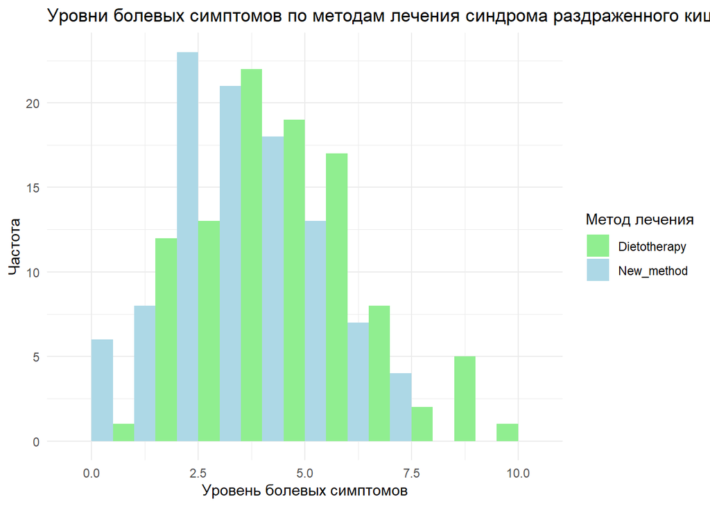

```r
# Преобразуем датафрейм в длинный формат
pain_data_tibs_long <- pivot_longer(treatment_irritable_bowel_syndrome,
                          cols = c(New_method, Dietotherapy),
                          names_to = "Treatment",
                          values_to = "Pain_Level")

# Теперь создадим гистограмму
ggplot(pain_data_tibs_long, aes(x = Pain_Level, fill = Treatment)) +
  geom_histogram(position = "dodge", binwidth = 1) +
  scale_fill_manual(values = c("New_method" = "lightblue", "Dietotherapy" = "lightgreen")) +
  labs(title = "Уровни болевых симптомов по методам лечения синдрома раздраженного кишечника",
       x = "Уровень болевых симптомов", y = "Частота", fill = "Метод лечения") +
  theme_minimal()
```

Теперь проведем тест Шапиро-Уилка и проверим нормальность распредедения:

```r
shapiro.test(treatment_irritable_bowel_syndrome$New_method)
```

```
##
##  Shapiro-Wilk normality test
##
## data:  treatment_irritable_bowel_syndrome$New_method
## W = 0.95756, p-value = 0.002703
```

```r
shapiro.test(treatment_irritable_bowel_syndrome$Dietotherapy)
```

```
##
##  Shapiro-Wilk normality test
##
## data:  treatment_irritable_bowel_syndrome$Dietotherapy
## W = 0.95208, p-value = 0.00114
```

```r
# Проведение двухвыборочного t-теста для независимых выборок
t_test_result <- t.test(pain_levels_new_treatment, pain_levels_dietotherapy)

# Вывод результатов теста
print(t_test_result)
```

```
##
##  Welch Two Sample t-test
##
## data:  pain_levels_new_treatment and pain_levels_dietotherapy
## t = -5.8671, df = 196.18, p-value = 1.86e-08
## alternative hypothesis: true difference in means is not equal to 0
## 95 percent confidence interval:
##  -2.030927 -1.009073
## sample estimates:
## mean of x mean of y
##      3.24      4.76
```

```r
critical_value <- qt(0.975, df = 196.18)  # Для двустороннего t-теста с альфа = 0.05
critical_value
```

```
## [1] 1.97213
```

- **P-value:** Значение p-value, составляющее 1.86e-08, подтверждает наличие статистически значимой разницы в средних уровнях болевых симптомов между пациентами, принимавшими участие в испытании нового метода лечения синдрома раздраженного кишечника, и теми, кто подвергался диетотерапии. Такая малая величина p-value даёт основания отклонить нулевую гипотезу (`H0`) в пользу альтернативной (`H1`), свидетельствуя о том, что введение нового метода лечения приводит к значительному улучшению состояния пациентов по сравнению с диетотерапией.
- **Доверительный интервал для разности средних:** Установленный доверительный интервал разности средних, охватывающий от -2.030927 до -1.009073 и не включающий в себя ноль, ещё раз подчёркивает статистическую значимость отмеченных различий. Отрицательные значения интервала подтверждают, что средний уровень болевых симптомов у группы, получившей новое лечение (в среднем 3.24), оказался ниже по сравнению с группой, проходившей диетотерапию (в среднем 4.76).
- **Наблюдаемое значение статистики (t-значение) и критическое значение:** Значение t-статистики, равное -5.8671, и степени свободы (df), равные 196.18, указывают на большую разницу между средними значениями двух групп, превышающую ожидаемую вариативность в рамках этих групп. При уровне значимости 0.05 и данных степенях свободы критическое значение t-статистики для двустороннего теста обычно находится в диапазоне около ±1.96. Наблюдаемое значение t-статистики значительно превышает этот порог, что дополнительно подтверждает статистическую значимость различий между группами.

Таким образом, исходя из результатов t-теста, можно делать вывод о значимом положительном эффекте нового метода лечения на уменьшение болевых симптомов синдрома раздраженного кишечника по сравнению с диетотерапией.

### **Задание 4**

Рассмотрите следующую гипотезу.

Проводится исследование, в котором исследуются три противоопухолевые препарата A, B плацебо (0) на трех группах мышей. В каждой из трех групп по 10 мышей. Оценивается размер опухоли у мыши.

Сгенерируйте датасет следующим образом:

```r
# Создание датафрейма
tumor <- tibble(
  therapy = c(rep("0", 10), rep("A", 10), rep("B", 10)),
  value = c(rep(3213, 10), rep(2687, 10), rep(2423, 10))
) %>%
  mutate(therapy = factor(therapy, levels = c("0", "A", "B")))

tumor$value <- tumor$value + rnorm(30, 0, 760)
```

- Постройте на одном графике три «ящика с усами» для наглядности.
- Проведите дисперсионный анализ, чтобы выяснить, есть ли разница между размером опухоли во всех группах.
- Прокомментируйте получившийся результат.
- С помощью функции `TukeyHSD()` проведите попарные сравнения, используя критерий Тьюки.
- Прокомментируйте полученные результаты.

Визуализация данных с помощью “ящика с усами”

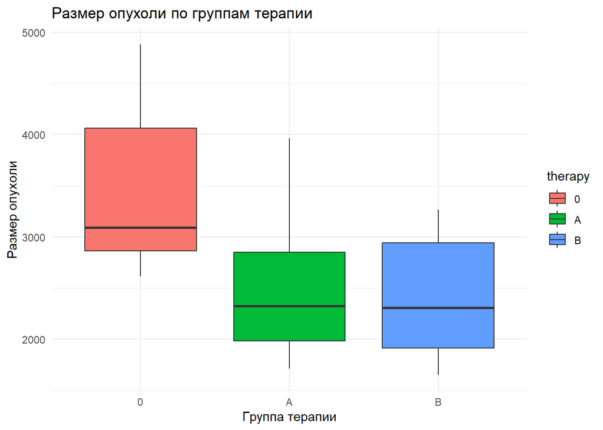

```r
ggplot(tumor, aes(x = therapy, y = value, fill = therapy)) +
  geom_boxplot() +
  labs(title = "Размер опухоли по группам терапии", x = "Группа терапии", y = "Размер опухоли") +
  theme_minimal()
```

Проведем дисперсионный анализ (ANOVA), чтобы выяснить, есть ли разница между размером опухоли во всех группах.

```r
# Проведение ANOVA
anova_result <- aov(value ~ therapy, data = tumor)
summary(anova_result)
```

```
##             Df   Sum Sq Mean Sq F value  Pr(>F)
## therapy      2  6308368 3154184   5.984 0.00706 **
## Residuals   27 14231691  527100
## ---
## Signif. codes:  0 '***' 0.001 '**' 0.01 '*' 0.05 '.' 0.1 ' ' 1
```

Результаты дисперсионного анализа (ANOVA) показывают наличие статистически значимых различий в размерах опухолей между группами мышей, получавших различные противоопухолевые препараты и плацебо.

Дисперсионный анализ не указывает, какие именно группы различаются, только подтверждает факт наличия этих различий. Для выяснения более конкретных парных различий между группами требуются дополнительные анализы, например, с использованием критерия Тьюки.

Проведем попарные сравнения с использования критерия Тьюки:

```r
# Попарные сравнения с критерием Тьюки
tukey_result <- TukeyHSD(anova_result)
tukey_result
```

```
##   Tukey multiple comparisons of means
##     95% family-wise confidence level
##
## Fit: aov(formula = value ~ therapy, data = tumor)
##
## $therapy
##           diff        lwr       upr     p adj
## A-0  -908.6621 -1713.6903 -103.6340 0.0245717
## B-0 -1026.1746 -1831.2027 -221.1464 0.0104421
## B-A  -117.5124  -922.5406  687.5157 0.9305253
```